# IP WEEK 12

REHEMA

2022-05-29

## 1. DEFINING THE QUESTION

### a) Specifying the Question

Which individuals are most likely to click on an ad?

### b) Defining the Metric of Success

Give conclusive recommendations based on the EDA results.

### c) Understanding the Context

A Kenyan entrepreneur has created an online cryptography course and would want to advertise it on her blog. She currently targets audiences originating from various countries. In the past, she ran ads to advertise a related course on the same blog and collected data in the process. She would now like to identify which individuals are most likely to click on her ads.

### d) Recording the Experimental Design

1. Load, preview and understand the data
2. Perform data cleaning and manipulation
3. Perform Exploratory Data Analysis
4. Give recommendations

## 2. READING THE DATA

```r
library("data.table")
library(tidyverse)
ads <- fread('http://bit.ly/IPAdvertisingData')
head(ads)
```

```
##    Daily Time Spent on Site Age Area Income Daily Internet Usage
## 1:                    68.95  35    61833.90               256.09
## 2:                    80.23  31    68441.85               193.77
## 3:                    69.47  26    59785.94               236.50
## 4:                    74.15  29    54806.18               245.89
## 5:                    68.37  35    73889.99               225.58
## 6:                    59.99  23    59761.56               226.74
##                            Ad Topic Line           City Male    Country
## 1:    Cloned 5thgeneration orchestration    Wrightburgh    0    Tunisia
## 2:    Monitored national standardization      West Jodi    1      Nauru
## 3:      Organic bottom-line service-desk       Davidton    0 San Marino
## 4: Triple-buffered reciprocal time-frame West Terrifurt    1      Italy
## 5:         Robust logistical utilization   South Manuel    0    Iceland
## 6:       Sharable client-driven software      Jamieberg    1     Norway
##              Timestamp Clicked on Ad
## 1: 2016-03-27 00:53:11             0
## 2: 2016-04-04 01:39:02             0
## 3: 2016-03-13 20:35:42             0
## 4: 2016-01-10 02:31:19             0
## 5: 2016-06-03 03:36:18             0
## 6: 2016-05-19 14:30:17             0
```

```r
# view the whole dataset
View(ads)
```

```r
# checking the datatype of each column
str(ads)
```

```
## Classes 'data.table' and 'data.frame':   1000 obs. of  10 variables:
##  $ Daily Time Spent on Site: num  69 80.2 69.5 74.2 68.4 ...
##  $ Age                     : int  35 31 26 29 35 23 33 48 30 20 ...
##  $ Area Income             : num  61834 68442 59786 54806 73890 ...
##  $ Daily Internet Usage    : num  256 194 236 246 226 ...
##  $ Ad Topic Line           : chr  "Cloned 5thgeneration orchestration" "Monitored national standardization" "Organic bottom-line service-desk" "Triple-buffered reciprocal time-frame" ...
##  $ City                    : chr  "Wrightburgh" "West Jodi" "Davidton" "West Terrifurt" ...
##  $ Male                    : int  0 1 0 1 0 1 0 1 1 1 ...
##  $ Country                 : chr  "Tunisia" "Nauru" "San Marino" "Italy" ...
##  $ Timestamp               : POSIXct, format: "2016-03-27 00:53:11" "2016-04-04 01:39:02" ...
##  $ Clicked on Ad           : int  0 0 0 0 0 0 0 1 0 0 ...
##  - attr(*, ".internal.selfref")=<externalptr>
```

## 3. Data Cleaning and Manipulation

### Missing values

```r
# check for missing values in the dataset
is.na(ads)
```

[output not shown]

[output cut: 1987 more lines]

```r
# Check for sum of missing values per column
colSums(is.na(ads))
```

```
## Daily Time Spent on Site                      Age              Area Income
##                        0                        0                        0
##     Daily Internet Usage            Ad Topic Line                     City
##                        0                        0                        0
##                     Male                  Country                Timestamp
##                        0                        0                        0
##            Clicked on Ad
##                        0
```

The results from checking for missing values in the whole dataset, there seemed to be none. This was confirmed by checking for the sum of missing values in the columns.

### Duplicates

```r
# Identifying any duplicated records
duplicates <- ads[duplicated(ads),]
duplicates
```

```
## Empty data.table (0 rows and 10 cols): Daily Time Spent on Site,Age,Area Income,Daily Internet Usage,Ad Topic Line,City...
```

There are no duplicates in the dataset

### Outliers

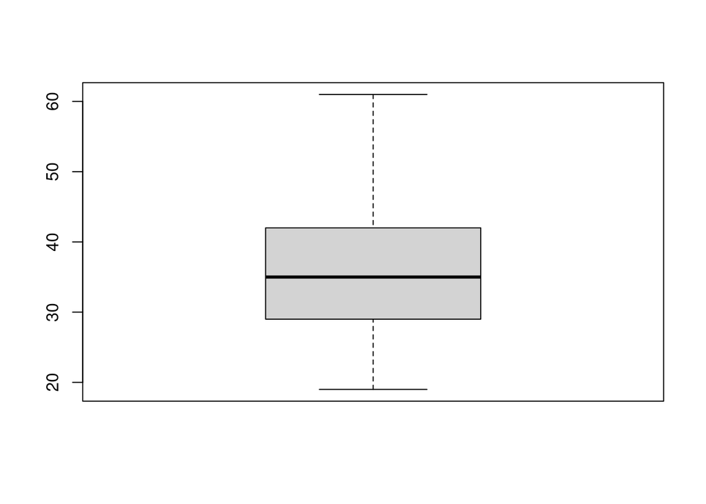

```r
# boxplot to visualize any outliers in the age column
boxplot(ads$Age)
```

There are no outliers in the age column.

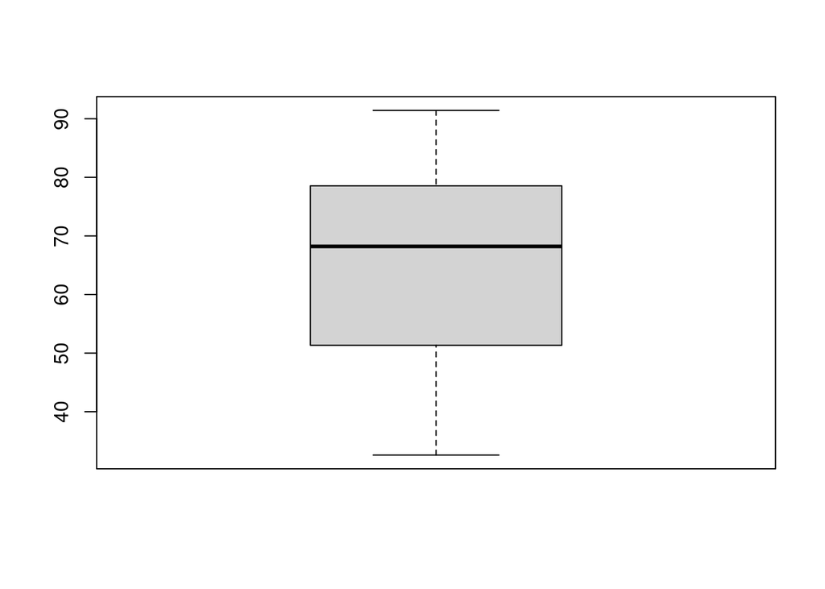

```r
# boxplot to visualize any outliers in the daily time spent on site column
boxplot(ads$'Daily Time Spent on Site')
```

There are no outliers in the daily time spent on site column.

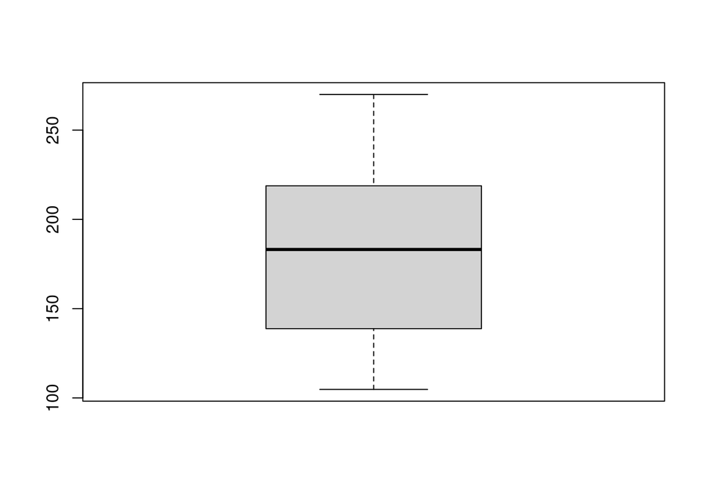

```r
# boxplot to visualize any outliers in the daily internet usage column
boxplot(ads$'Daily Internet Usage')
```

There are no outliers in the daily internet usage column.

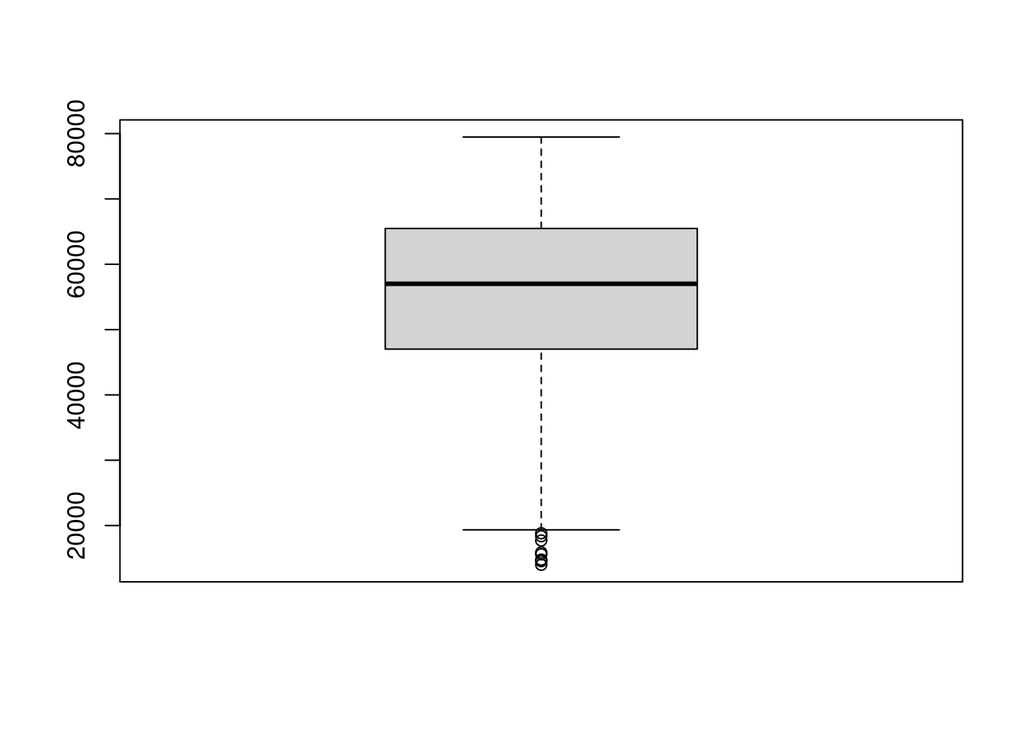

```r
# boxplot to visualize any outliers in the area income column
boxplot(ads$'Area Income')
```

There are outliers in the area income column, which I’m not going to remove as it might interfere with analysis.

## 4. Exploratory Data Analysis

### Univariate Analysis

```r
# Summary Statistics
summary(ads)
```

```
##  Daily Time Spent on Site      Age         Area Income    Daily Internet Usage
##  Min.   :32.60            Min.   :19.00   Min.   :13996   Min.   :104.8
##  1st Qu.:51.36            1st Qu.:29.00   1st Qu.:47032   1st Qu.:138.8
##  Median :68.22            Median :35.00   Median :57012   Median :183.1
##  Mean   :65.00            Mean   :36.01   Mean   :55000   Mean   :180.0
##  3rd Qu.:78.55            3rd Qu.:42.00   3rd Qu.:65471   3rd Qu.:218.8
##  Max.   :91.43            Max.   :61.00   Max.   :79485   Max.   :270.0
##  Ad Topic Line          City                Male         Country
##  Length:1000        Length:1000        Min.   :0.000   Length:1000
##  Class :character   Class :character   1st Qu.:0.000   Class :character
##  Mode  :character   Mode  :character   Median :0.000   Mode  :character
##                                        Mean   :0.481
##                                        3rd Qu.:1.000
##                                        Max.   :1.000
##    Timestamp                   Clicked on Ad
##  Min.   :2016-01-01 02:52:10   Min.   :0.0
##  1st Qu.:2016-02-18 02:55:42   1st Qu.:0.0
##  Median :2016-04-07 17:27:29   Median :0.5
##  Mean   :2016-04-10 10:34:06   Mean   :0.5
##  3rd Qu.:2016-05-31 03:18:14   3rd Qu.:1.0
##  Max.   :2016-07-24 00:22:16   Max.   :1.0
```

From the output above, we can deduce the following: - The mean daily time spent on site is 65.00 - The mean age is 36 - The mean area income is 55000 - The mean daily internet usage is 180.0

- The median daily time spent on site is 68.22
- The median age is 35
- The median area income is 57012
- The median daily internet usage is 183.1
- The maximum and minimum daily time spent on site are 91.43 and 32.60
- The maximum and minimum age are 61 and 19
- The maximum and minimum area income are 79485 and 13996
- The maximum and minimum daily internet usage are 270.0 and 104.8
- The first and third quartiles in daily time spent on site are 51.36 and 78.55
- The first and third quartiles in age are 29 and 42
- The first and third quartiles in area income are 47032 and 65471
- The first and third quartiles in daily internet usage are 138.8 and 218.8

```r
# getting the mode
getmode <- function(v) {
   uniqv <- unique(v)
   uniqv[which.max(tabulate(match(v, uniqv)))]
}

age.mode <- getmode(ads$Age)
age.mode
```

```
## [1] 31
```

```r
time.mode <- getmode(ads$`Daily Time Spent on Site`)
time.mode
```

```
## [1] 62.26
```

```r
income.mode <- getmode(ads$`Area Income`)
income.mode
```

```
## [1] 61833.9
```

```r
usage.mode <- getmode(ads$`Daily Internet Usage`)
usage.mode
```

```
## [1] 167.22
```

- The most popular age is 31
- The most people spend 62.26 on a site
- The most popular area income is 61833.9
- The most people spend 167.22 on internet access

```r
# getting the range
age.range <- max(ads$Age) - min(ads$Age)
age.range
```

```
## [1] 42
```

```r
time.range <- max(ads$`Daily Time Spent on Site`) - min(ads$`Daily Time Spent on Site`)
time.range
```

```
## [1] 58.83
```

```r
income.range <- max(ads$`Area Income`) - min(ads$`Area Income`)
income.range
```

```
## [1] 65488.3
```

```r
usage.range <- max(ads$`Daily Internet Usage`) - min(ads$`Daily Internet Usage`)
usage.range
```

```
## [1] 165.18
```

```r
# getting the variance (how the data values is dispersed around the mean)
age.var <- var(ads$Age)
age.var
```

```
## [1] 77.18611
```

```r
time.var <- var(ads$`Daily Time Spent on Site`)
time.var
```

```
## [1] 251.3371
```

```r
income.var <- var(ads$`Area Income`)
income.var
```

```
## [1] 179952406
```

```r
usage.var <- var(ads$`Daily Internet Usage`)
usage.var
```

```
## [1] 1927.415
```

```r
# getting the standard deviation
age.stdev <- sd(ads$Age)
age.stdev
```

```
## [1] 8.785562
```

```r
time.stdev <- sd(ads$`Daily Time Spent on Site`)
time.stdev
```

```
## [1] 15.85361
```

```r
income.stdev <- sd(ads$`Area Income`)
income.stdev
```

```
## [1] 13414.63
```

```r
usage.stdev <- sd(ads$`Daily Internet Usage`)
usage.stdev
```

```
## [1] 43.90234
```

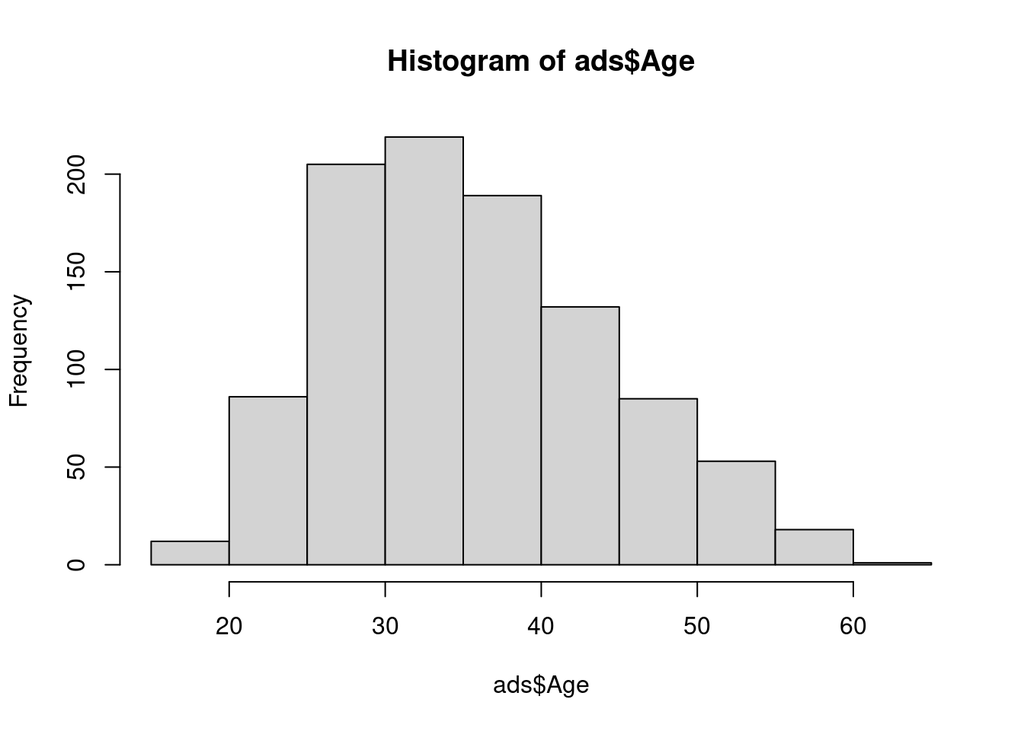

```r
# plotting a histogram for age
hist(ads$Age)
```

```r
# plotting a bar graph for male
sex <- ads$Male

sex_freq <- table(sex)
sex_freq
```

```
## sex
##   0   1
## 519 481
```

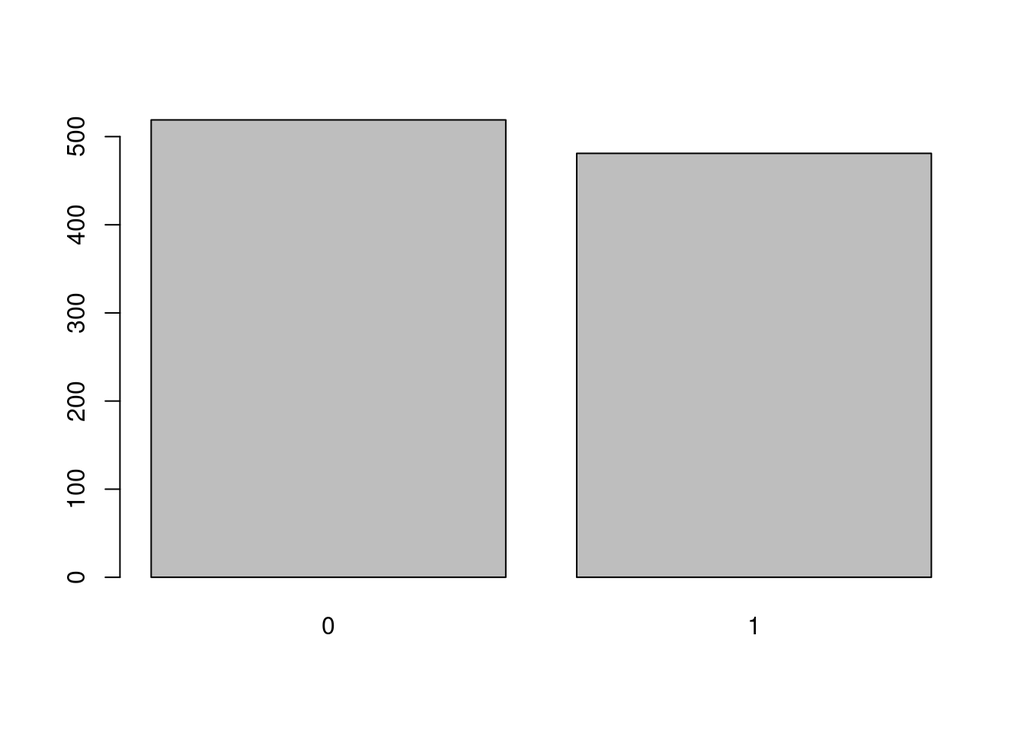

```r
barplot(sex_freq)
```

```r
# plotting a bar graph for clicked on ad
click <- ads$`Clicked on Ad`

click_freq <- table(click)
click_freq
```

```
## click
##   0   1
## 500 500
```

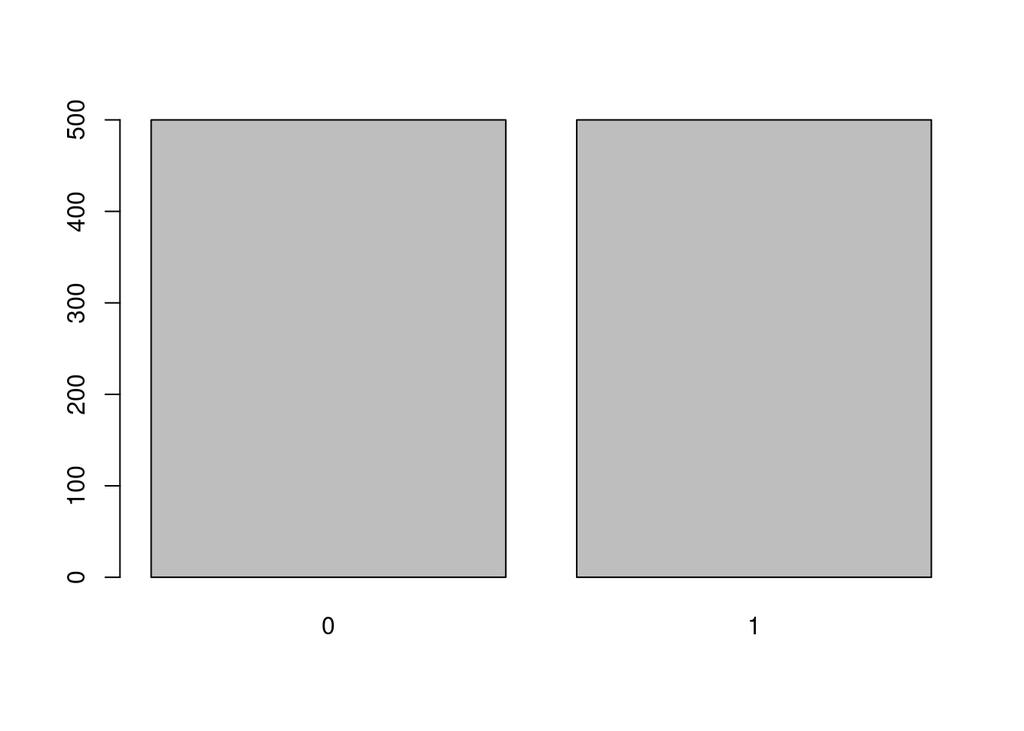

```r
barplot(click_freq)
```

The frequency of clicking on an ad or not is the same

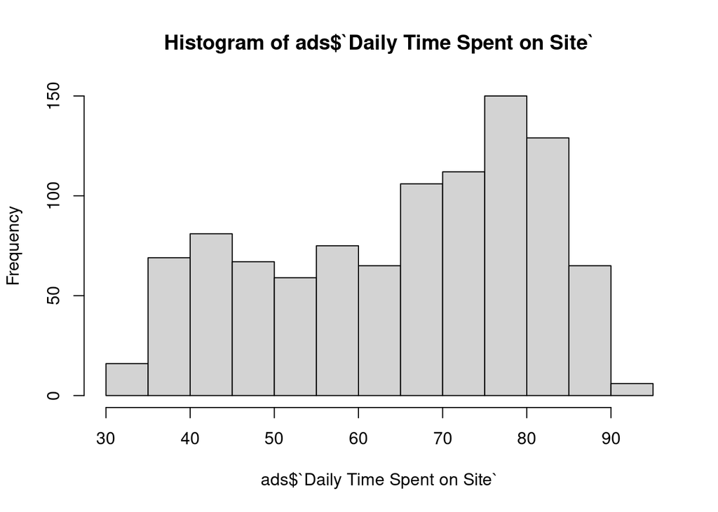

```r
# plotting a histogram for daily time spent on site
hist(ads$`Daily Time Spent on Site`)
```

Most people spend between 75 and 85 units of time on a site with the ad

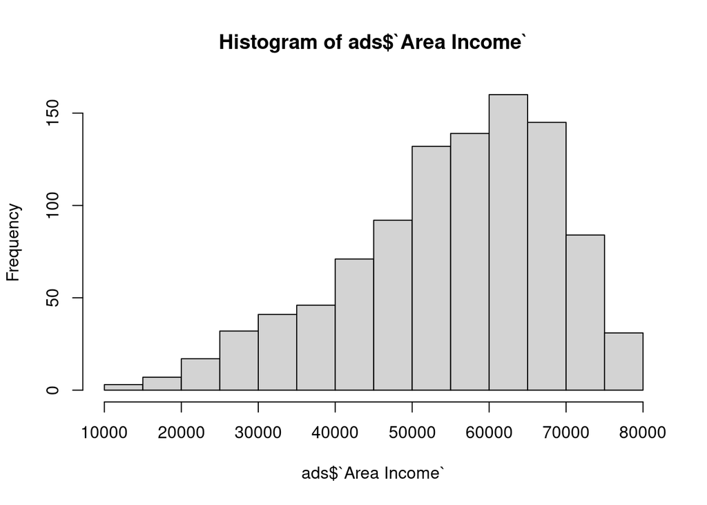

```r
# plotting a histogram for area income
hist(ads$`Area Income`)
```

The distribution for area income is skewed to the left with most incomes being between 50000 and 70000

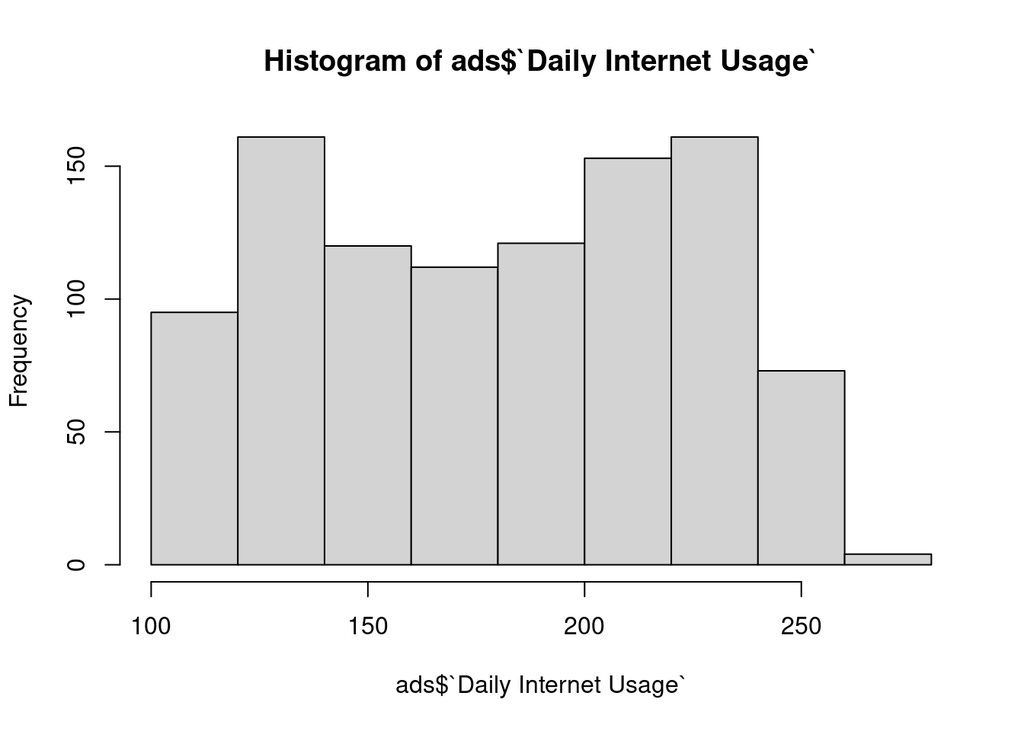

```r
# plotting a histogram for daily internet usage
hist(ads$`Daily Internet Usage`)
```

### Bivariate Analysis

```r
# covariance
cov(ads$`Daily Time Spent on Site`, ads$Age)
```

```
## [1] -46.17415
```

```r
cov(ads$`Daily Time Spent on Site`, ads$`Area Income`)
```

```
## [1] 66130.81
```

```r
cov(ads$`Daily Time Spent on Site`, ads$`Daily Internet Usage`)
```

```
## [1] 360.9919
```

```r
cov(ads$`Daily Time Spent on Site`, ads$`Clicked on Ad`)
```

```
## [1] -5.933143
```

```r
cov(ads$`Daily Time Spent on Site`, ads$Male)
```

```
## [1] -0.1501864
```

```r
cov(ads$Age, ads$`Area Income`)
```

```
## [1] -21520.93
```

```r
cov(ads$Age, ads$`Daily Internet Usage`)
```

```
## [1] -141.6348
```

```r
cov(ads$Age, ads$`Clicked on Ad`)
```

```
## [1] 2.164665
```

```r
cov(ads$Age, ads$Male)
```

```
## [1] -0.09242142
```

```r
cov(ads$`Area Income`, ads$`Daily Internet Usage`)
```

```
## [1] 198762.5
```

```r
cov(ads$`Area Income`, ads$`Clicked on Ad`)
```

```
## [1] -3195.989
```

```r
cov(ads$`Area Income`, ads$Male)
```

```
## [1] 8.867509
```

```r
cov(ads$`Clicked on Ad`, ads$Male)
```

```
## [1] -0.00950951
```

The covariance between daily time spent on site, area income and daily internet usage are positive indicating a positive linear relationship between the variables. The covariance between age, daily time spent on site, area income and daily internet usage are negative, indicating a negative linear relationship between the variables. The covariance between area income and clicking on ad is negative, indicating a negative linear relationship between the variables.

```r
# Correlation Coefficient
cor(ads$`Daily Time Spent on Site`, ads$Age)
```

```
## [1] -0.3315133
```

```r
cor(ads$`Daily Time Spent on Site`, ads$`Area Income`)
```

```
## [1] 0.3109544
```

```r
cor(ads$`Daily Time Spent on Site`, ads$`Daily Internet Usage`)
```

```
## [1] 0.5186585
```

```r
cor(ads$`Daily Time Spent on Site`, ads$`Clicked on Ad`)
```

```
## [1] -0.7481166
```

```r
cor(ads$`Daily Time Spent on Site`, ads$Male)
```

```
## [1] -0.01895085
```

```r
cor(ads$Age, ads$`Area Income`)
```

```
## [1] -0.182605
```

```r
cor(ads$Age, ads$`Daily Internet Usage`)
```

```
## [1] -0.3672086
```

```r
cor(ads$Age, ads$`Clicked on Ad`)
```

```
## [1] 0.4925313
```

```r
cor(ads$Age, ads$Male)
```

```
## [1] -0.02104406
```

```r
cor(ads$`Area Income`, ads$`Daily Internet Usage`)
```

```
## [1] 0.3374955
```

```r
cor(ads$`Area Income`, ads$`Clicked on Ad`)
```

```
## [1] -0.4762546
```

```r
cor(ads$`Area Income`, ads$Male)
```

```
## [1] 0.001322359
```

```r
cor(ads$`Clicked on Ad`, ads$Male)
```

```
## [1] -0.03802747
```

Most of the variables are negatively linearly correlated or weakly correlated.

```r
# Computing correlation
x = ads%>%
#x <- cor
select(`Daily Time Spent on Site`, Age,`Area Income`, `Daily Internet Usage`, Male, `Clicked on Ad`)
corr = cor(x)
corr
```

```
##                          Daily Time Spent on Site         Age  Area Income
## Daily Time Spent on Site               1.00000000 -0.33151334  0.310954413
## Age                                   -0.33151334  1.00000000 -0.182604955
## Area Income                            0.31095441 -0.18260496  1.000000000
## Daily Internet Usage                   0.51865848 -0.36720856  0.337495533
## Male                                  -0.01895085 -0.02104406  0.001322359
## Clicked on Ad                         -0.74811656  0.49253127 -0.476254628
##                          Daily Internet Usage         Male Clicked on Ad
## Daily Time Spent on Site           0.51865848 -0.018950855   -0.74811656
## Age                               -0.36720856 -0.021044064    0.49253127
## Area Income                        0.33749553  0.001322359   -0.47625463
## Daily Internet Usage               1.00000000  0.028012326   -0.78653918
## Male                               0.02801233  1.000000000   -0.03802747
## Clicked on Ad                     -0.78653918 -0.038027466    1.00000000
```

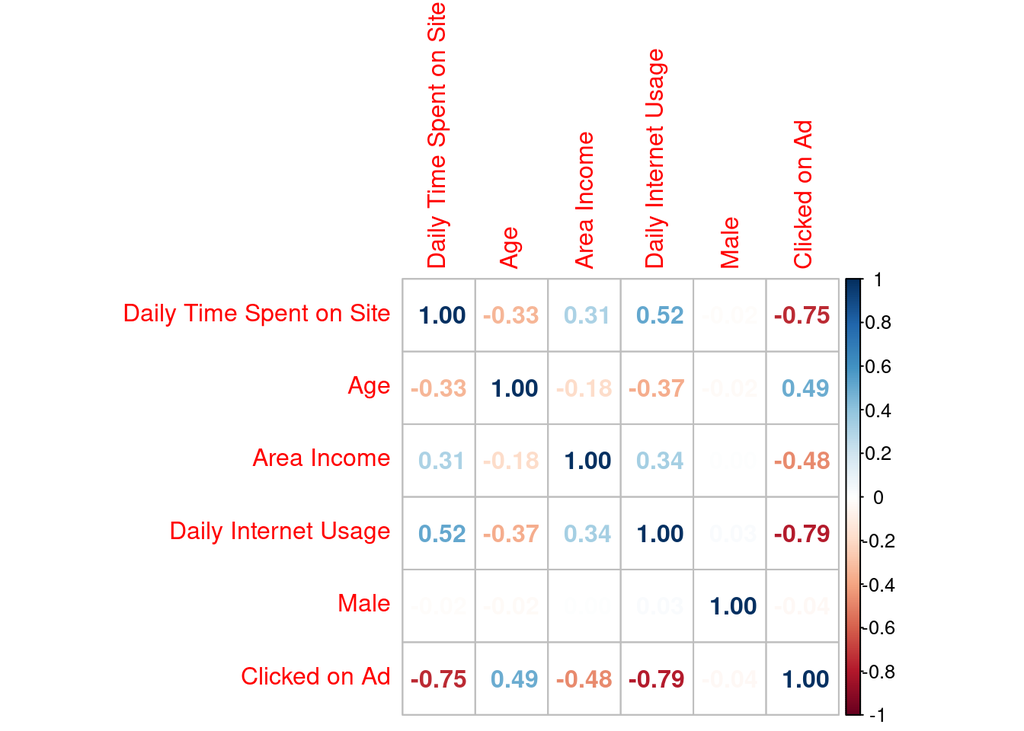

```r
library(corrplot)
corrplot(corr, method="number", sig.level = 0.01, insig = "blank")
```

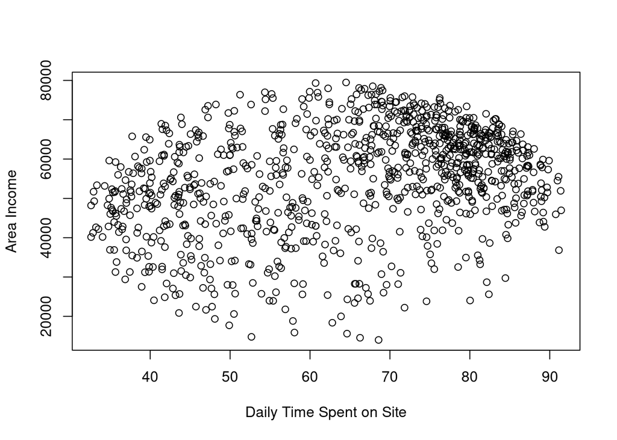

```r
plot(ads$`Daily Time Spent on Site`, ads$`Area Income`, xlab="Daily Time Spent on Site", ylab="Area Income")
```

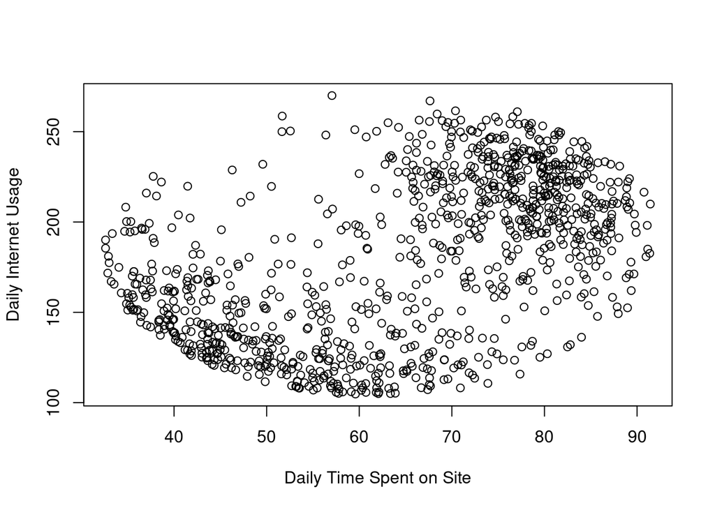

```r
plot(ads$`Daily Time Spent on Site`, ads$`Daily Internet Usage`, xlab="Daily Time Spent on Site", ylab="Daily Internet Usage")
```

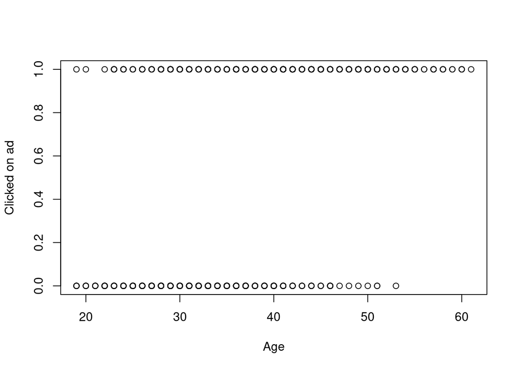

```r
plot(ads$Age, ads$`Clicked on Ad`, xlab="Age", ylab="Clicked on ad")
```

```r
# order data based on clicked on ad
ads_sort <- ads[order(ads$`Clicked on Ad`), ]
ads_sort
```

```
##       Daily Time Spent on Site Age Area Income Daily Internet Usage
##    1:                    68.95  35    61833.90               256.09
##    2:                    80.23  31    68441.85               193.77
##    3:                    69.47  26    59785.94               236.50
##    4:                    74.15  29    54806.18               245.89
##    5:                    68.37  35    73889.99               225.58
##   ---
##  996:                    43.70  28    63126.96               173.01
##  997:                    72.97  30    71384.57               208.58
##  998:                    51.30  45    67782.17               134.42
##  999:                    51.63  51    42415.72               120.37
## 1000:                    45.01  26    29875.80               178.35
##                               Ad Topic Line           City Male
##    1:    Cloned 5thgeneration orchestration    Wrightburgh    0
##    2:    Monitored national standardization      West Jodi    1
```

[output cut: 21 more lines]

```r
# getting the top 10 countries with the maximum number of ad clicks
library(dplyr)

group.country.adline = ads %>% group_by(Country) %>%
                   summarise(total_clicks = sum(`Clicked on Ad`),
                             .groups = 'drop')
group.country.adline %>% arrange(desc(total_clicks))
```

```
## # A tibble: 237 × 2
##    Country       total_clicks
##    <chr>                <int>
##  1 Australia                7
##  2 Ethiopia                 7
##  3 Turkey                   7
##  4 Liberia                  6
##  5 Liechtenstein            6
##  6 South Africa             6
##  7 Afghanistan              5
##  8 France                   5
##  9 Hungary                  5
## 10 Mayotte                  5
## # … with 227 more rows
```

```r
View(group.country.adline)
```

The top 10 countries with the most ad clicks are Australia, Ethiopia, Turkey, Liberia, Liechtenstein, South Africa, Afghanistan, France, Hungary and Mayotte

```r
# getting the top 10 cities with the maximum number of ad clicks
library(dplyr)

group.city = ads %>% group_by(City) %>%
                   summarise(total_clicks = sum(`Clicked on Ad`),
                             .groups = 'drop')
group.city %>% arrange(desc(total_clicks))
```

```
## # A tibble: 969 × 2
##    City         total_clicks
##    <chr>               <int>
##  1 Lake David              2
##  2 Lake James              2
##  3 Lisamouth               2
##  4 Michelleside            2
##  5 Millerbury              2
##  6 Robertfurt              2
##  7 South Lisa              2
##  8 West Amanda             2
##  9 West Shannon            2
## 10 Williamsport            2
## # … with 959 more rows
```

```r
View(group.city)
```

The top 10 cities with the most ad clicks are Lake David, Lake James, Lisamouth, Michelleside, Millerbury, Robertfurt, South Lisa, West Amanda, West Shannon, Williamsport

```r
# getting the top 10 ad topic lines with the maximum number of ad clicks
library(dplyr)

group.ad = ads %>% group_by(`Ad Topic Line`) %>%
                   summarise(total_clicks = sum(`Clicked on Ad`),
                             .groups = 'drop')
group.ad %>% arrange(desc(total_clicks))
```

```
## # A tibble: 1,000 × 2
##    `Ad Topic Line`                             total_clicks
##    <chr>                                              <int>
##  1 Adaptive asynchronous attitude                         1
##  2 Adaptive context-sensitive application                 1
##  3 Adaptive contextually-based methodology                1
##  4 Adaptive demand-driven knowledgebase                   1
##  5 Adaptive uniform capability                            1
##  6 Advanced 24/7 productivity                             1
##  7 Advanced disintermediate data-warehouse                1
##  8 Advanced systemic productivity                         1
##  9 Advanced web-enabled standardization                   1
## 10 Ameliorated bandwidth-monitored contingency            1
## # … with 990 more rows
```

```r
View(group.ad)
```